# DATA 605 Assignment Week 13

Peter Gatica

2022-11-20

```r
library(knitr)
```

##### 1. Use integration by substitution to solve the integral below.

$$\int 4e^{-7x}dx$$
$$u=-7x\ \rightarrow du=-7dx\ \rightarrow
dx=\frac{du}{-7}$$
thus
$$\int
4e^{u}\frac{du}{-7} \rightarrow \frac{4}{-7} \int e^{u}du\rightarrow
\frac{4}{-7} e^{u}+C$$
finally
$$\frac{4}{-7} e^{-7x}+C$$

##### 2. Biologists are treating a pond contaminated with bacteria. The level of contamination is changing at a rate of

$$\frac{dN}{dt} =-\frac{3150}{t^{4}} -220$$

##### bacteria per cubic centimeter per day, where t is the number of days since treatment began. Find a

##### function N(t) to estimate the level of contamination if the level after 1 day was 6530 bacteria per cubic

##### centimeter.

$$dN=(-\frac{3150}{t^{4}}
-220)dt\rightarrow N=\int -\frac{3150}{t^{4}} -220dt\rightarrow N=\int
-\frac{3150}{t^{4}} dt-\int 22dt\rightarrow N=-\frac{3150}{3t^{3}}
-220t+C$$

```r
t <- 1
(N <- (-3150/(3*t^3)-(220*1)))
```

```
## [1] -1270
```

```r
(C <- 6530 - N )
```

```
## [1] 7800
```

##### (3) Find the total area of the red rectangles in the figure below, where the equation of the line is f(x) = 2x-9.

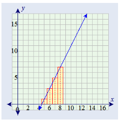

```r
plot_area_img <- "/Users/Audiorunner13/CUNY MSDS Course Work/DATA605 Fall 2022/Week 13/plot_area.png"
# attr(transplant_prop_img, "info")
include_graphics(plot_area_img)
```

$$\int^{8.5}_{4.5} 2x-9dx=[x^{2}-9x]\mid^{8.5}_{4.5}$$

```r
x1 <- 8.5
x2 <- 4.5
(pArea <- (x1^2-(9*x1))-(x2^2-(9*x2)))
```

```
## [1] 16
```

Area = 16

##### (4) Find the area of the region bounded by the graphs of the given equations

$$y=x^{2}-2x-2,\ y=x+2$$

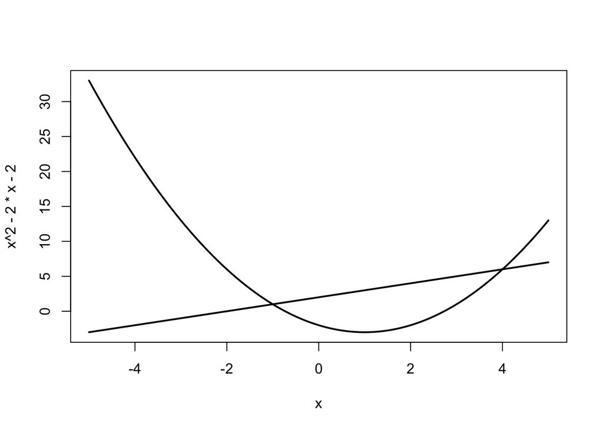

```r
curve(x^2-2*x-2, lwd = 2, xlim=c(-5, 5))
curve(x+2, lwd = 2, xlim=c(-5, 5), add = TRUE)
```

Intersects at x = -1 and x = 4

$$\int^{4}_{-1} x+2dx-\int^{4}_{-1}
x^{2}-2x-2dx=-[\frac{1}{3} x^{3}-\frac{3}{2} x^{2}-4x]\mid^{4}_{-1}$$

```r
(pArea <- 18.67 + 2.12)
```

```
## [1] 20.79
```

##### Area = 20.79

##### (5) A beauty supply store expects to sell 110 flat irons during the next year. It costs $3.75 to store one flat

##### iron for one year. There is a fixed cost of $8.25 for each order. Find the lot size and the number of orders per

##### year that will minimize inventory costs.

I could not figure this one out. :-(

##### (6) Use integration by parts to solve the integral below.

$$\int ln(9x)\times x^{6}dx$$
$$u=ln(9x),\frac{dv}{dx} =x^{6}\rightarrow
du=\frac{9}{9x} dx=\frac{1}{x} dx\rightarrow dv=x^{6}dx$$
$$v=\frac{1}{7} x^{7}$$
thus

$$\int udv=uv-\int
vdu\ =\ ln(9x)\frac{1}{7} x^{7}-\int \frac{1}{7} x^{7}\frac{1}{x}
dx\ =\ ln(9x)\frac{x^{7}}{7} -\frac{x^{7}}{49} -C$$

##### (7) Determine whether f(x) is a probability density function on the interval [1,e^6]. If not, determine the value of

##### the definite integral.

$$f(x)=\frac{1}{6x}$$

$$\int^{e^{6}}_{1}
f(x)dx=\int^{e^{6}}_{1} \frac{1}{6x} dx=\frac{1}{6} \int^{e^{6}}_{1}
\frac{1}{x} dx=\frac{1}{6} ln(x)\mid^{e^{6}}_{1}$$

$$=\frac{1}{6} \left[
ln(e^{6})-ln(1)\right] =\frac{1}{6} \left[ 6-0\right] =1$$